A_M1014YF01_3S3RNA

Drowsy False

----------------------------

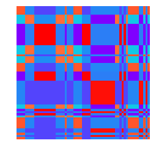

69

A_M1014YF01_3S3RNA

Drowsy False

----------------------------

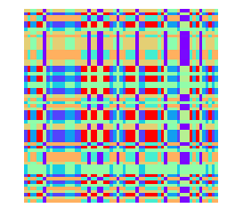

70

A_M1014YF01_3S3RNA

Drowsy False

----------------------------

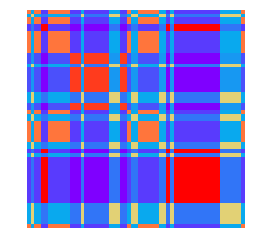

71

A_M1014YF01_3S3RNA

Drowsy False

----------------------------

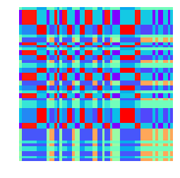

72

A_M1014YF01_3S3RNA

Drowsy False

----------------------------

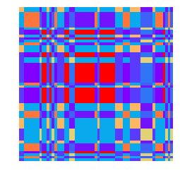

73

A_M1014YF01_3S3RNA

Drowsy False

----------------------------

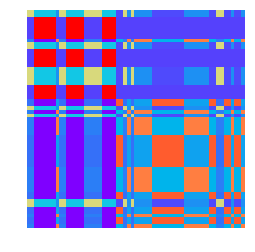

74

A_M1014YF01_3S3RNA

Drowsy False

----------------------------

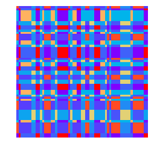

75

A_M1014YF01_3S3RNA

Drowsy False

----------------------------

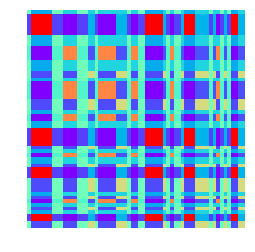

76

A_M1014YF01_3S3RNA

Drowsy False

----------------------------

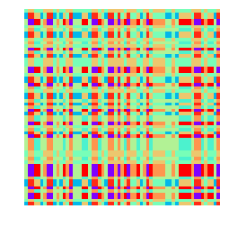

77

A_M1016YF02_1S2RNA

Drowsy False

----------------------------

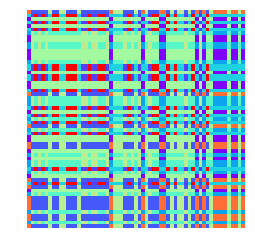

78

A_M1016YF02_1S2RNA

Drowsy False

----------------------------

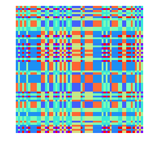

79

A_M1016YF02_1S2RNA

Drowsy False

----------------------------